# Marketing Research

MKTG 440

Exam 1 Review

# Discussion

- Thinking Forward
- Office hours
- Class next week

# Exam 1 details

## Exam information

- **Duration**: 70 minutes
  - Class start time – 5 minutes before class ends
- **Materials Allowed**:
  - Can bring 1 page of notes, front and back
- **Device Policy**:
  - Turn off all sounds and vibrations. Don’t wear/take out any devices while in the room.
- **When finished, turn in**:
  1. Exam sheet
  2. Bubble sheet
  3. Note sheet

## Format and preparation

- **Format**:
  - Multiple Choice (~20)
  - Short Answer (~2-3)
- **Study Resources**:
  - Review slides and your notes
  - Practice exam (D2L → Content → Resources)
  - Identify and practice areas of weakness
  - Office hours

## Pull up practice exam

- MC: first one free
- SA4

## Topics I’ll go over today*

- The marketing research process
  - Problem framing
- Research designs
  - Exploratory, Descriptive, Causal
  - Focus groups & projective techniques
  - Causation & experiments
- Measurement & Scaling
  - Scale types (N, O, I, R)
  - Central tendency
  - Scale quality (validity, reliability)
  - Constructs & Likert scales
- Questionnaire design
  - Formulation biases
  - Measurement issues
  - Getting the best answers
  - Survey structure
- Sampling
  - Population and sample
  - Sampling frames & frame error
  - Sampling vs. non-sampling error
  - Probability sampling methods
  - Non-probability sampling methods

*Not every detail reelvant to the exam will be covered today, but I will hit the main points.

Please interrupt me with questions. I do not have a whole class worth of material prepared.

# The marketing research process

## The marketing research process flow

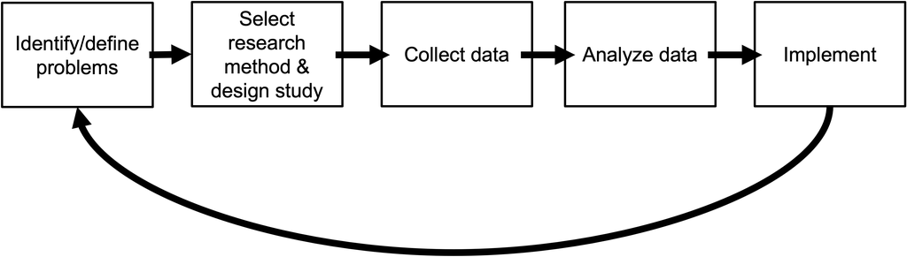

## Management vs. research questions

- **Management question**: A question relating to managerial outcomes (action-oriented, focuses on symptoms)
- **Research question**: A question relating to information needed by the decision maker (information-oriented, focuses on underlying causes)

| Management questions (symptoms) | Marketing research questions (root problems) |
| --- | --- |
| How do we increase market share? How do we decrease churn? | What are the drivers of choice and switching? Which segments are we underperforming in, and why? Where in the funnel are we losing customers? |

## Problem framing framework

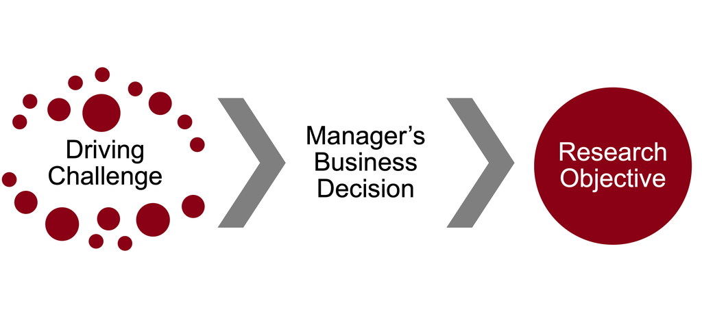

# Research designs

## Qualitative vs. quantitative research

| Factor | Qualitative Methods | Quantitative Methods |
| --- | --- | --- |
| **Goals** | Discovery of new ideas and thoughts; preliminary understanding of relationships | Validation of facts, estimates, relationships |
| **Research objectives** | Exploratory | Descriptive and causal |
| **Type of questions** | Open-ended, unstructured, probing | Mostly structured |
| **Representativeness** | Small samples | Large samples with a focus on sampling |
| **Type of analysis** | Debriefing, subjective, thematic analysis | Statistical, descriptive, causal |
| **Generalizability** | Often limited | Generalizable if done correctly |

## Exploratory research

**Exploratory research:** Research used to generate ideas, clarify concepts and the nature of problems, and to establish research priorities.

- Get ideas and define terms/concepts
- Uncover future research questions
- Establish research priorities
- Typically takes place first (before descriptive or causal research)

**Methods:** In-depth interviews, focus groups, projective techniques

## In-depth interviews

**In-depth interview:** An interview where a trained interviewer asks a respondent a set of structured probing questions.

- Typically one-on-one
- 30-60 minutes
- Focused – no other participants to impress, few distractions
- Opportunities for more detailed discussion (follow-ups)

## Focus groups

**Focus group:** A moderated group discussion designed to surface language, motivations, beliefs, and reactions to ideas.

- Typically 5-10 participants
- 60-90 minutes
- Participants selected via purposive sampling (not random)
- Moderator asks questions, stimulates, and controls the direction

**Key tradeoffs vs. interviews:** Group dynamics (organic discussion vs. groupthink), sensitive topics, efficiency, representativeness

## Projective techniques

**Projective technique:** A form of questioning that encourages respondents to project their underlying motivations, beliefs, attitudes, or feelings…

- Onto a third party, into a task situation, or onto an inanimate object

**Types:** Role playing, word association, sentence completion, cartoon (balloon) test, third-person technique

**Pros**

- Elicit responses subjects may be unwilling/unable to give
- Useful for sensitive topics
- Useful for subconscious motivations

**Cons**

- Require highly trained interviewers
- Risk of **interpretation bias**
- Engage people in unusual behaviors

## Descriptive research

**Descriptive research:** Research targeted at describing the characteristics of an existing marketing situation.

- Questions related to **who, what, where, when, how**
- Mostly Quantitative

**Common data collection approaches:**

- **Observational data** (secondary): Store audits, consumer panels, TV/media panels, social media monitoring
- **Surveys and questionnaires** (primary)

## Surveys: pros and cons

**Pros**

- **Easy** – easy to administer to large numbers
- **Reliable** – standardization reduces variability
- **Efficient** – easy coding, analysis, interpretation

**Cons**

- **Non-response** – people don’t always respond
- **Rigid** – difficult to capture beliefs or feelings
- **Sensitive** – properly wording questions is not easy
- **Sampling** – tough to get the right sample

Most survey-based marketing research today is conducted via **online surveys** (low cost, speed, ease of targeting, scalable).

## Causal research

**Causal relationship:** “When you do X, Y will happen”

Three Factors Necessary for Causation

**1. Correlation (Concomitant Variation)**

- Evidence of association between X and Y

**2. Temporal Antecedence**

- X must occur before Y

**3. No Third Factor**

- No other factor (Z) driving both X and Y

## Experiments: treatment and control

**Causal Research designs:** Study the causal effects of changing something (X) on an outcome (Y).

- **Independent variable (IV)**: What the researcher changed
- **Dependent variable (DV)**: Measures of outcomes
- **Treatment group**: Exposed to the manipulation
- **Control group**: Not exposed to the manipulation
- **Random assignment**: Participants randomly assigned to conditions
  - Avoids selection effects by balancing individual differences across groups

**Experiments/RCTs/A-B tests are the ONLY research designs that rigorously establish causality.**

## Internal vs. external validity

**Internal validity:** Ability to confidently draw causal conclusions

- How clean is the experiment? Is it free of confounds?

**External validity:** Ability to generalize from research setting to other contexts (the real world)

- Is the environment so controlled that results are useless?

**Difficult to achieve both high internal AND external validity**

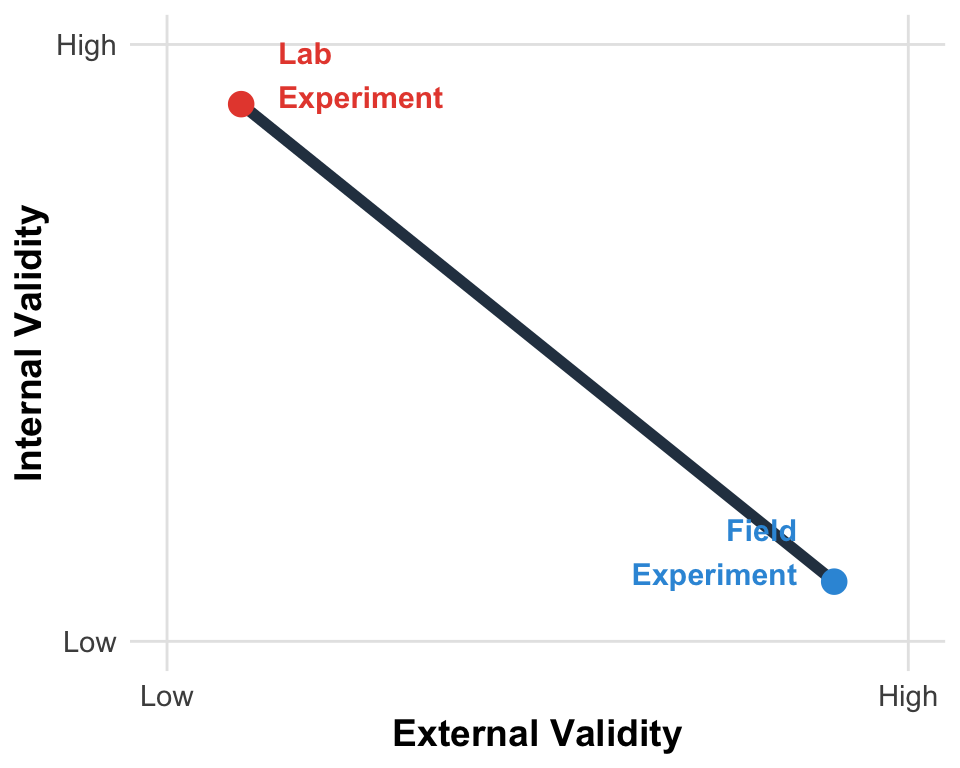

## Lab vs. field experiments

**Lab Experiments**

- Artificial (controlled) setting
- Lab’s subject pool
- **Pro:** Limited extraneous variables; quick and inexpensive
- **Con:** Not a natural setting (generalization may be a problem)
- Higher **internal** validity

**Field Experiments**

- Natural setting (supermarkets, online)
- **Pro:** Generalizable
- **Con:** Expensive and time-consuming; difficult to control extraneous variables; no secrecy
- Higher **external** validity

## Confounds

A **confound (third factor)** is a factor that influences both the dependent variable and independent variable.

**Example:** You want to learn the effect of container shape on soda consumption. You fill a can with Pepsi and a bottle with Coke, then randomly assign participants.

- **DV:** Amount consumed
- **IV:** Container shape (can vs. bottle)
- **Confound:** Soda brand (Pepsi vs. Coke) – varies with the IV

# Measurement and scaling

## Four types of scales

1. **Nominal scale**: Categories/labels
2. **Ordinal scale**: Nominal + order
3. **Interval scale**: Ordinal + equal intervals
4. **Ratio scale**: Interval + true zero

| Property | Nominal | Ordinal | Interval | Ratio |
| --- | --- | --- | --- | --- |
| Describe | ✓ | ✓ | ✓ | ✓ |
| Preserve order |  | ✓ | ✓ | ✓ |
| Equal intervals |  |  | ✓ | ✓ |
| Natural zero |  |  |  | ✓ |

## Scales and central tendency

|  | Nominal | Ordinal | Interval | Ratio |
| --- | --- | --- | --- | --- |
| **Mode** | Appropriate | Appropriate | Appropriate | Appropriate |
| **Median** | Inappropriate | Appropriate | Appropriate | Appropriate |
| **Mean** | Inappropriate | Inappropriate | Appropriate | Appropriate |

Moving from nominal to ratio:

- Information content increases
- More math/stats can be used
- Greater burden on participants

## Scale quality

**Reliability:** Consistency – ability to get the same result repeatedly

- **Test-retest reliability**: same sample, same scale, two different times
- **Internal consistency**: highly correlated answers between questions measuring the same construct
- **Equivalent forms**: high correlation between two similar scales

**Validity:** Accuracy – whether it measures what it is supposed to measure

- **Face validity**: does it *look like* it measures the right thing?
- **Content validity**: does it cover *all aspects* of the construct?

**Sensitivity:** A scale’s ability to detect differences that exist in the construct

## Constructs and Likert scales

**Constructs** are abstract concepts that are not directly observable or measurable (e.g., customer satisfaction, brand loyalty, perceived quality).

**Measuring constructs:**

1. Identify the construct (e.g., brand loyalty)
2. Identify dimensions/factors (e.g., repeat purchase, satisfaction, advocacy)
3. Use multiple survey items (Likert scales) to measure each dimension
4. Combine into a composite score

**Likert scales:**

- Typically 5, 7, or 9 response options (odd number allows neutral midpoint)
- We *assume* equal intervals between points – this allows us to calculate means
- Combine multiple Likert items to create a composite score
- Use pre-defined scales and labels when possible

# Questionnaire design

## Formulation biases

**Ambiguity:** “Which brand of shampoo do you use?” – specify who, what, when, where

**Leading questions:** Introduce bias by suggesting desired answers

- “Retail experts believe that all consumers should comparison shop. Do you agree?”

**Loaded questions:** Assume something about the respondent or involve emotionally charged issues

- “Should Americans buy imported automobiles that take away American jobs?”

**Double-negatives:** “Do you oppose not allowing the passage of Proposition 418?”

- Fix: “Do you support or oppose Proposition 418?”

## Measurement issues in surveys

**Nominal issues:**

- **Not collectively exhaustive:** “Which computer do you own? Windows PC / Apple” – missing options
- **Double-barreled questions:** “Is Sprite tasty AND refreshing?” – asking two things at once; split into two questions

**Ordinal issues:**

- **Ambiguous responses:** “How often do you shop? Never / Occasionally / Sometimes / Often / Regularly” – use concrete categories (e.g., “1 or 2 times”, “3 or 4 times”)

**Interval/ratio issues:**

- **Bad intervals:** Missing a scale point (e.g., 4-point Likert skipping “Agree”) – use pre-configured scales
- **Bad range:** Slider $0-$20 when answers could be $0-$1000

## Getting the best answers

Three key questions:

1. **Do we care what they have to say?** – Use **screening/filter questions** to identify qualified respondents
2. **Do they know the answer?** – Provide **memory aids** (checklists vs. open-ended) and reduce **cognitive load**
3. **Are they willing to tell us?** – For sensitive topics: desensitize questions, use projective techniques, hide the true nature of the survey

## Unstructured vs. structured questions

|  | **Unstructured (Open-Ended)** | **Structured (Closed-Ended)** |
| --- | --- | --- |
| **Examples** | Sentences, unaided recall | Multiple choice, dichotomous, scaled response |
| **Pros** | Rich information; good for exploratory research | Easier for respondent; easier to code and analyze; less interviewer error |
| **Cons** | Burdensome for respondent; difficult to analyze | Less flexible; not good for exploratory research |

## Questionnaire layout: the funnel approach

1. **Introduction**: Topic, expectations, time estimate, consent, incentives
2. **Screening questions**: Identify qualified respondents
3. **Research questions**: General to specific (funnel approach); create sections of similar content
4. **Last section**: Sensitive topics and demographics

**Order effects:** Systematic change in responses caused by question position

- *Learning/priming*: Earlier questions change what’s “top of mind”
- *Fatigue*: Later questions get less attention

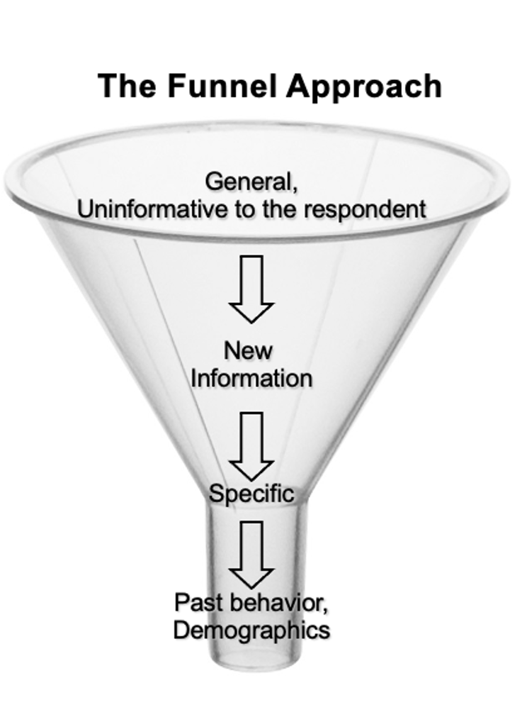

# Sampling

## Why do we sample?

- **Goal:** Make claims about a population
- **Problem:** Impossible to collect data on everyone (a census is costly)
  - US Census (2020): $15.6B for 9 pieces of information on 300M+ people
- **Solution:** Select a subset (sample) and generalize

**Population:** The entire group of interest. A **parameter** describes a characteristic of the population (e.g., population mean $\mu$).

**Sample:** The subset we collect data from. A **statistic** describes a characteristic of the sample (e.g., sample mean $\bar{x}$).

## Sampling frame

A **sampling frame** is, ideally, a list of every person/object in the target population.

- Can be expensive and time-consuming to create
- Examples: customer/membership list, registered voter list, email list
- Difficult to be exhaustive (complete)

## Sampling frame error

- Sampling frame error is any mismatch between the sampling frame and the target population (undercoverage or overcoverage)

## Sampling vs. non-sampling error

**Sampling error:** Differences between a sample statistic and a population parameter that result from using a sample instead of a census.

- Unavoidable, but can be quantified (confidence intervals, p-values)
- Bigger sample size = smaller sampling error

**Non-sampling error:** Error caused by our sampling method or data collection process.

- **Sampling frame error**: frame does not represent the target population
- **Non-response error**: respondents choose not to participate (mitigate with incentives)
- **Response error**: respondents provide incorrect information (mitigate with better survey design)

## Probability vs. non-probability sampling

**Probability**

- Every element has a non-zero probability of inclusion
- Allows quantification of sampling error
- Methods: Simple Random, Systematic, Stratified, Cluster

**Non-probability**

- Elements selected in a non-random manner
- Usually based on researcher’s judgement
- No guarantee sample is representative
- Methods: Convenience, Judgmental, Quota, Snowball

## Probability sampling methods

**Simple Random Sampling (SRS):** Each element has the same, known, non-zero probability of inclusion.

- Advantage: Simple; favorable statistical properties
- Disadvantage: Requires a complete, accurate sampling frame

**Systematic Sampling:** Select every *k*-th element from the population list (skip interval *k* = population size / sample size).

- Advantage: More efficient than SRS; useful when frame isn’t digitized
- Disadvantage: Hidden patterns can cause bias if *k* aligns with a cyclical pattern

## Probability sampling methods

**Stratified Sampling:** Divide the population into strata, then randomly sample from each stratum.

- Elements *within* a stratum are homogeneous; *across* strata are heterogeneous
- Advantage: Ensures important subgroups are represented; more representative
- Disadvantage: Need complete sampling frame; hard to identify right strata

**Cluster Sampling:** Divide the population into clusters, then randomly select entire clusters.

- Elements *within* a cluster are heterogeneous (opposite of stratified)
- Advantage: More cost-effective; only need frame for selected clusters
- Disadvantage: Less representative; higher sampling error

## Stratified vs. cluster sampling

**Cluster Sampling**

- Sample *whole clusters* (groups)
- Elements differ within a cluster; compositions of clusters are similar
- Only need sampling frame for selected clusters
- Increases **efficiency** (lower cost)

**Stratified Sampling**

- Sample *within* specific strata
- Elements homogeneous within strata; heterogeneous between strata
- Need complete sampling frame for all strata
- Increases **representativeness**

## Non-probability sampling methods

**Convenience sampling:** Sample of convenient elements (right place, right time). Least expensive but not representative.

**Judgmental (purposive) sampling:** Elements selected based on researcher’s judgment. Popular for qualitative studies (e.g., focus groups).

**Quota sampling:** Develop quotas for control characteristics, then use convenience/judgment to fill each quota. Ensures key subgroups are represented, but still relies on judgment.

**Snowball sampling:** Start with a few participants, ask them to refer others. Useful for hard-to-reach populations (e.g., undocumented immigrants). Risk of community bias.

## The central limit theorem

- **If** the sample size is sufficiently large ($\geq$ 30)
- **Then** regardless of the shape of the population distribution, the sampling distribution of means will be approximately normal

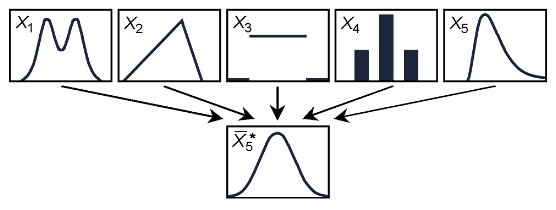

We use the CLT to develop statistical tests and quantify uncertainty in our sample.

## Sample size formula

$$n = \frac{Z^2 \times \sigma^2}{e^2}$$

Where:

- $\sigma^2$ = Population variance (estimated from pilot or prior knowledge)
- $Z$ = Confidence level (e.g., $Z = 1.96$ for 95% confidence)
- $e$ = Acceptable margin of error

**Example:** Estimate mean satisfaction (0-10 scale), $\sigma = 2.5$, 95% confidence, $e = 0.50$:

$$n = \frac{(1.96)^2(6.25)}{(0.50)^2} \approx 97$$

## Good luck on the exam!

- Bring your 1-page note sheet (front and back)
- Bring a pencil for the bubble sheet
- Know your student ID (write it on your note sheet)

# Questions?

- About specific topics or concepts?
- About the practice exam?
- About …?

MKTG 440 | Prof. Nolan